# Introduction to ggplot2 (Part 2)

Gregor Mathes

2020-21-04

# 1 Overview

This is the second part of the introduction to ggplot2, written for the palaeobiology master students at Uni Erlangen. You can find the **first part** on the [evolvED homepage](https://www.evolv-ed.net/post/introduction-to-ggplot2-part-i/).  
Here, we will dive a little bit deeper into ggplot2 and see how we can modify the default output of ggplot. In the end you will be able to personalise a plot to fit your needs, enabling you to produce publication ready plots within the R environment.  
You can find all exercises, solutions, and source code for this introduction in my [github repository](https://github.com/Ischi94/ggplot_intro).  
Please note that ggplot might be a gateway drug to the tidyverse. Unfortunately, this is neither an introduction to the tidyverse nor an exhaustive report showing you every detail of ggplots. If needed, I can provide an intro to the tidyverse within the next weeks. Ggplot offers the chance to produce *any* graph you can think of. Use your power wisely.

# 2 Retrospect

In part 1, we’ve learned how to **call a ggplot** with `ggplot()` and add various **layers** to it. We’ve learned how to map data to **aesthetics** to answer a few basic questions. An alternative approach to mapping aesthetics was **facetting**. We dealt with various **geometries** including trend lines, boxplots, histograms, barplots, and line plots. We looked a bit under the hood of ggplot when we examined the **statistics** of each geom.

# 3 Scales

Scales control the mapping from data to aesthetics. They take your data and transform it into visuals, like size, colour, position or shape. Scales also produce the axes and legends. We already produced plots without actively modifying the underlying scales, which still resulted in nice plots. However, modifying scales gives us much more control, and is the first thing you should think about when you want to modify a plot.

## 3.1 Modifying scales

Whenever we don’t specify a scale in our `ggplot()` call, ggplot uses the default scale. If you want to override the defaults, you’ll need to add the scale ourself. You can do that with our **+** operator.

```r
ggplot(mpg, aes(displ, hwy)) +
  geom_point(aes(colour = class)) +
  scale_x_continuous("This is my label for the x-axis") +
  scale_y_continuous("This is my label for the y-axis")
```

There exists a specific naming scheme for scales made up of three pieces, each separated by an underscore "_".

1. `scale`
2. The name of the aesthetic (e.g., `colour`, `shape` or `x`)
3. The name of the scale (e.g., `continuous`, `discrete`, `brewer`)

RStudio makes your life easier by giving you suggestions when you type `scale`. Just select the one you need.

## 3.2 Guides

The component of a scale that we want to modify quite often is the **guide**, the axis or legend associated with the scale. As mentioned before, ggplot produces those for you by default (*note that this is a big difference to base R, where you have to do everything by your own when it comes to legends*). The important part here is that you used a clear mapping between your data and aesthetics, so that ggplot understands what we want it to do. We can modify every component of the axis and legend:

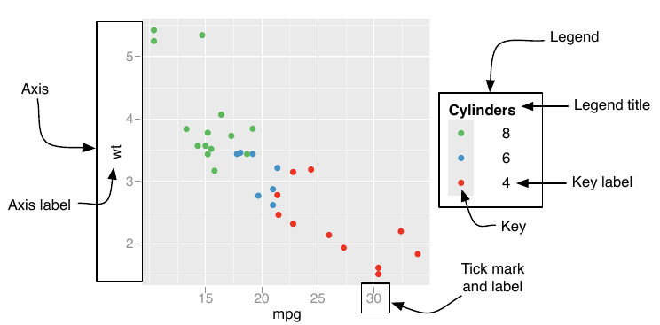

.

### 3.2.1 Labels/ titles

The first argument to the scale function, `name`, is the axes/legend title:

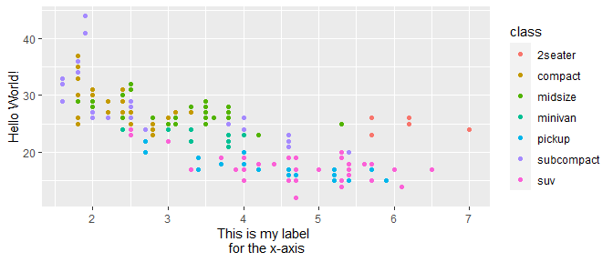

```r
ggplot(mpg, aes(displ, hwy)) +
  geom_point(aes(colour = class)) +
  scale_x_continuous("This is my label \n for the x-axis") +
  scale_y_continuous("Hello World!")
```

As you will do this quite ofte, people have already produced shortcuts for you: `xlab()`, `ylab()` and `labs()`.

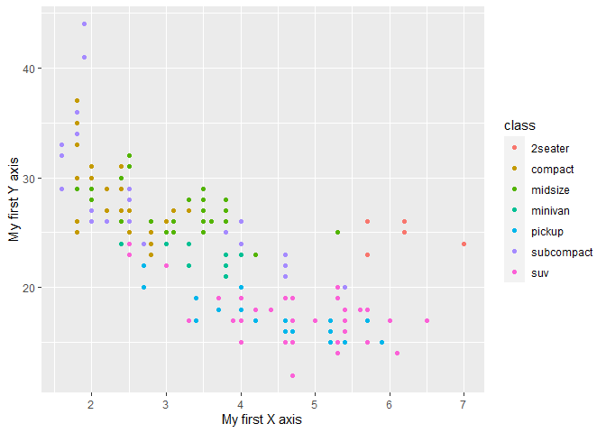

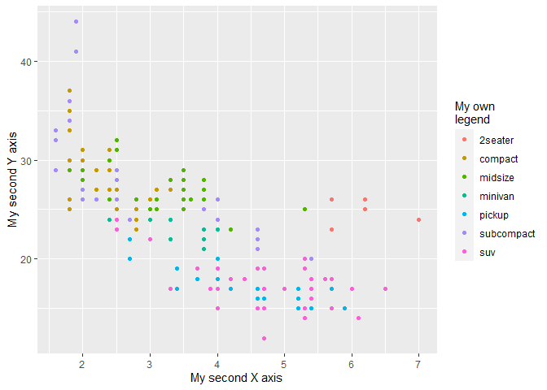

```r
my_plot <- ggplot(mpg, aes(displ, hwy)) + geom_point(aes(colour = class))
my_plot +
  xlab("My first X axis") +
  ylab("My first Y axis")
my_plot + labs(x = "My second X axis", y = "My second Y axis", colour = "My own\nlegend")
```

To remove axis labels, you have to set `x` or `y` = `NULL`. If you set them = `""`, you will produce an empty space instead of removing the label.

### 3.2.2 Breaks/ labels

The `breaks` argument controls which values appear as tick marks on axes and keys on legends. Each break has an associated `label`, controlled by the `labels` argument. If you set `labels`, you must also set `breaks`; otherwise, if data changes, the breaks will no longer align with the labels.

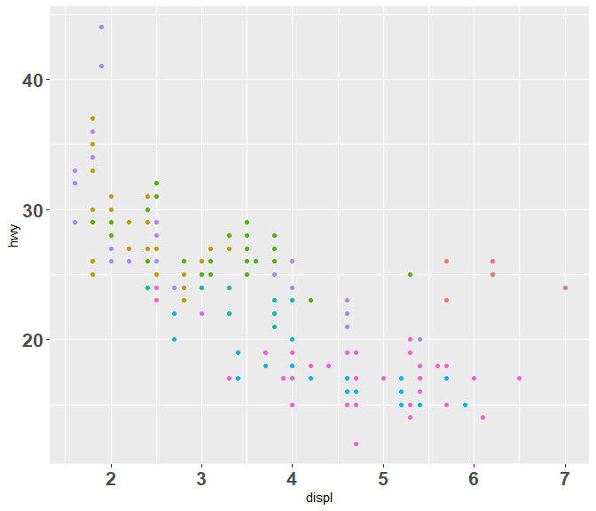

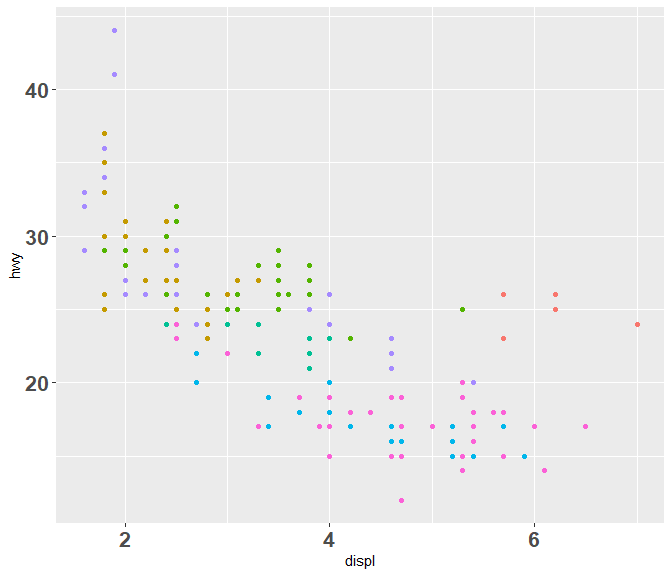

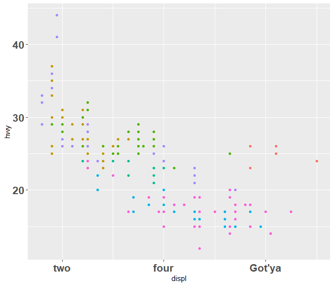

```r
my_plot
my_plot + scale_x_continuous(breaks = c(2, 4, 6))
my_plot + scale_x_continuous(breaks = c(2, 4, 6), labels = c("two", "four", "Got'ya"))
```

Same with legend breaks:

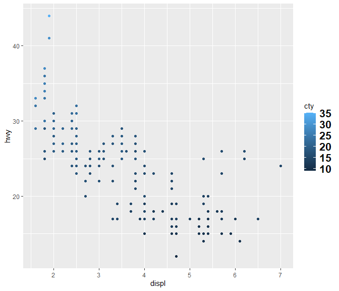

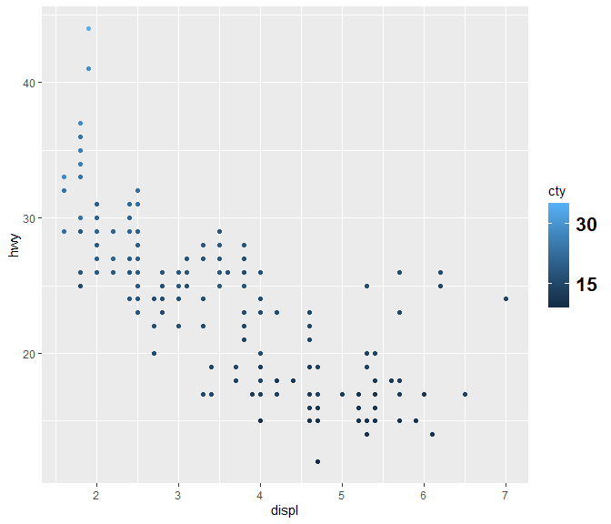

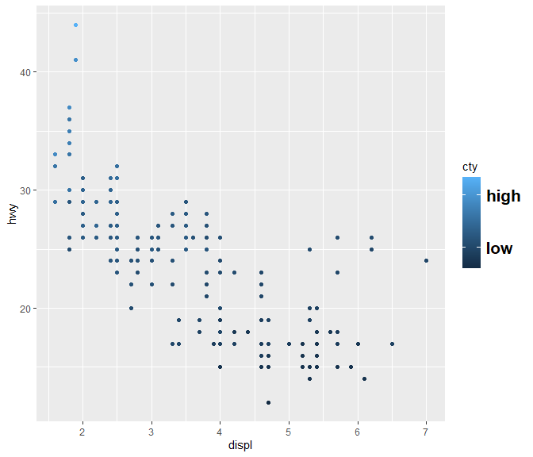

```r
my_plot
my_plot + scale_colour_continuous(breaks = c(15, 30))
my_plot + scale_colour_continuous(breaks = c(15, 30), labels = c("low", "high"))
```

## 3.3 Scale transformations

It might be helpful to transform your data when plotting, to see patterns emerging. This is particularly interesting in your exploratory analysis part, where you just plot things and then see where this is going. With ggplot2, you don’t have to do this manually before plotting. Transforming your scales will save you time and energy, while ggplot2 makes nice line breaks and everything. Every continuous scale takes a `trans` argument, allowing the use of a variety of transformations:

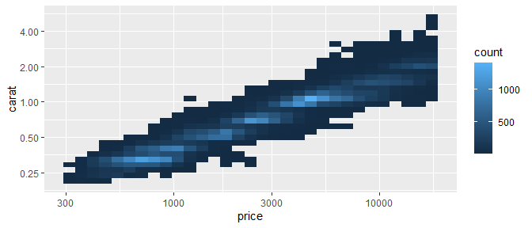

```r
ggplot(diamonds, aes(price, carat)) +
  geom_bin2d() +
  scale_x_continuous(trans = "log10") +
  scale_y_continuous(trans = "log2")
```

There are shortcuts for the most common: `scale_x_log10()`, `scale_x_sqrt()` and `scale_x_reverse()` (and similarly for y.)

## 3.4 Colours

Colours are a difficult topic and it’s always good to have the underlying basics of colour theory in your mind when you produce a plot for a presentation, website or a publication. I’ve found myself quite often spending hours and hours trying out different colours for one plot. Luckily, ggplot2 offers some sensitive defaults and shortcuts. We will spent a bit more time on colours now, as they are really important when it comes to plots.

### 3.4.1 Continuous

Colour gradients are often used to show the height of a 2d surface. In the following example we’ll use the surface of a 2d density estimate of the `faithful` dataset (Azzalini and Bowman 1990, within the ggplot2 package), which records the waiting time between eruptions and during each eruption for the Old Faithful geyser in Yellowstone Park. I hide the legends and set expand to 0, to focus on the appearance of the data. This expands to plot to allign with the axis lines, instead of having some space there by default.

```r
erupt <- ggplot(faithfuld, aes(waiting, eruptions, fill = density)) +
  geom_raster() +
  scale_x_continuous(NULL, expand = c(0, 0)) +
  scale_y_continuous(NULL, expand = c(0, 0)) +
  theme(legend.position = "none")
```

There are four continuous colour scales:

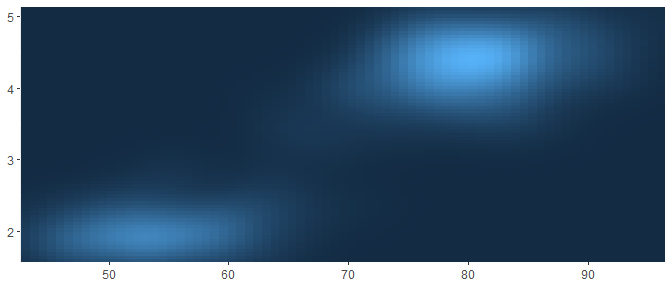

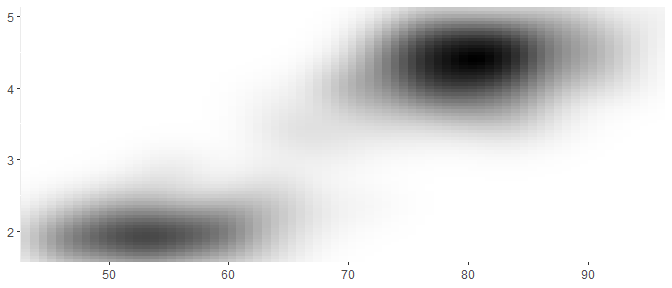

```r
erupt

erupt + scale_fill_gradient(low = "white", high = "black")
```

- `scale_colour_gradient2()` and `scale_fill_gradient2()`: a three-colour gradient, low-med-high (default is red-white-blue). As well as low and high colours, these scales also have a mid colour for the colour of the midpoint. The midpoint defaults to 0, but can be set to any value with the midpoint argument.

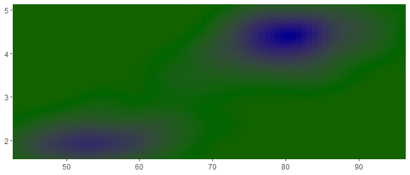

```r
mid <- median(faithfuld$density)
erupt + scale_fill_gradient2(midpoint = mid, low = "darkred", mid = "darkgreen",
                             high = "darkblue")
```

- `scale_colour_gradientn()` and `scale_fill_gradientn()`: a custom n-colour gradient. This is useful if you have colours that are meaningful for your data (just ask Nussaibah about her terrain map), or you’d like to use a palette produced by another package (like *colorspace* or *RColorBrewer*).

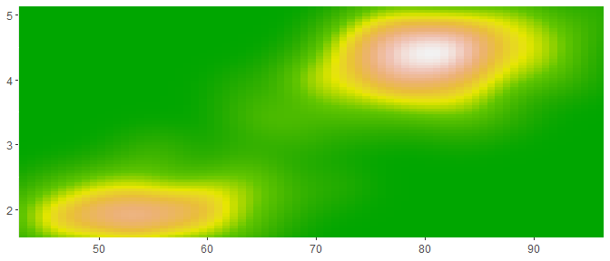

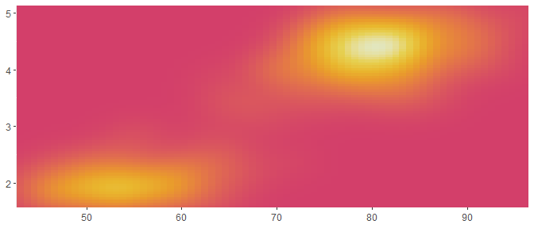

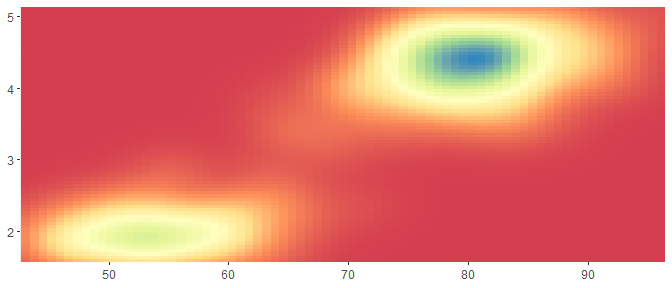

```r
erupt + scale_fill_gradientn(colours = terrain.colors(7))
erupt + scale_fill_gradientn(colours = colorspace::heat_hcl(7))
erupt + scale_fill_gradientn(colours =  RColorBrewer::brewer.pal(7, "Spectral"))
```

- `scale_color_distiller()` and `scale_fill_distiller()` apply the ColorBrewer colour scales to continuous data. You use it the same way as `scale_fill_brewer()`, described later.

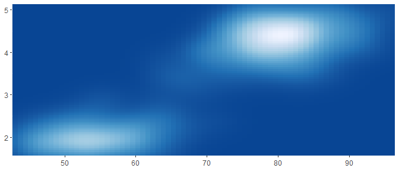

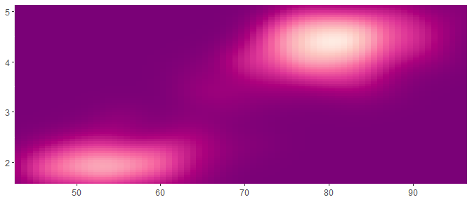

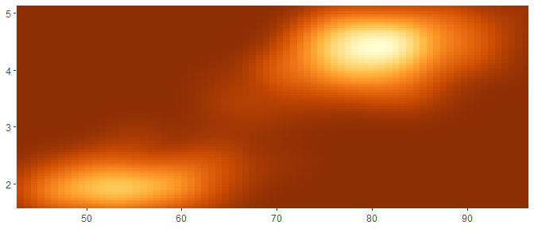

```r
erupt + scale_fill_distiller()
erupt + scale_fill_distiller(palette = "RdPu")
erupt + scale_fill_distiller(palette = "YlOrBr")
```

### 3.4.2 Discrete

There are four colour scales for discrete data:

- The default colour scheme, `scale_colour_hue()`, picks evenly spaced hues around the HCL colour wheel. This works well for up to about eight colours, but after that it becomes hard to tell the different colours apart. You can control the default chroma and luminance, and the range of hues, with the `h`, `c` and `l` arguments:

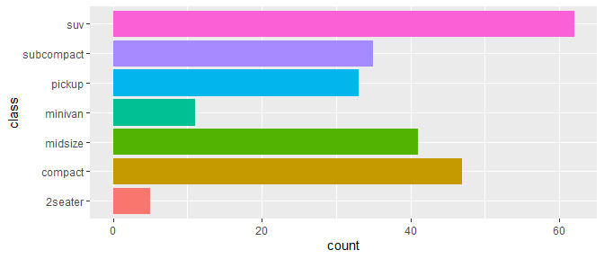

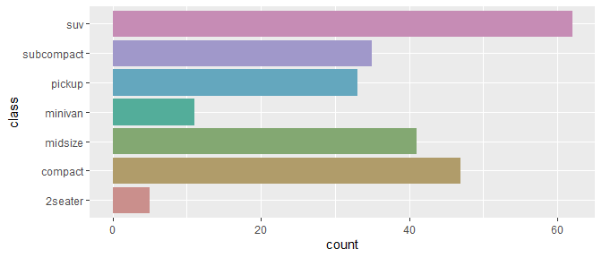

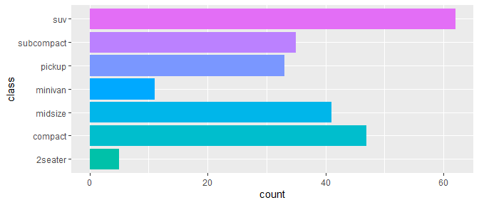

```r
my_bars
my_bars + scale_fill_hue(c = 40)
my_bars + scale_fill_hue(h = c(180, 300))
```

- `scale_colour_brewer()` uses handpicked ColorBrewer colours, from the [RColorBrewer package](http://colorbrewer2.org/). These colours have been designed to work well in a wide variety of situations, although the focus is on maps and so the colours tend to work better when displayed in large areas.
- `scale_colour_grey()` maps discrete data to grays, from light to dark.
- `scale_colour_manual()` is useful if you have your own discrete colour palette. You can even use them with colours inspired by Wes Anderson movies, as provided by the [wesanderson package](https://github.com/karthik/wesanderson).  
  Instead of mapping a colour palette to your data, you can use the `values` parameter of `scale_colour_manual()` (or `scale_fill_manual()`, depending on your aesthetics) to manually specify the values that the scale should produce:

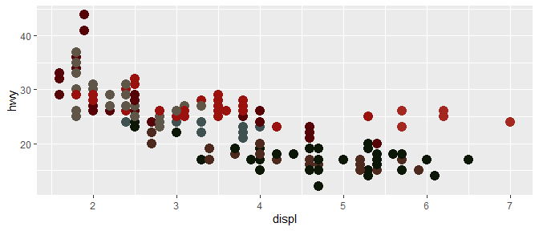

```r
my_plot + scale_colour_manual(values = wesanderson::wes_palette("BottleRocket1"))
```

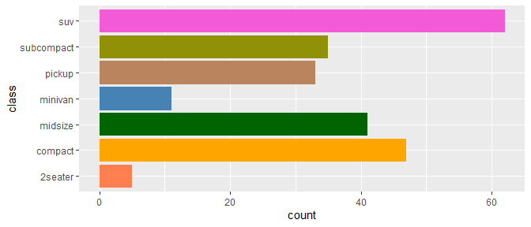

```r
my_bars +
  scale_fill_manual(values = c("coral", "orange", "darkgreen", "steelblue", "#ba855e", "#919108", "#f25ad8"))
```

You can steel colours from your favourite artist using the [colortheft webpage](https://colortheft.com/).  
Like I already mentioned, it is always important to think about what you want to visualise and what message you want to convey. There is not the one colour palette to fit all your needs, play around with them and see what fits. Also: bright colours work well for points, but are overwhelming on bars. Subtle colours work well for bars, but are hard to see on points.

# 4 Legends

While axes and legends share most parameters, some options only apply to legends, as they are more complex than axes.

1. A legend can display multiple aesthetics (e.g. colour and shape), from multiple layers, and the symbol displayed in a legend varies based on the geom used in the layer.
2. Axes always appear in the same place. Legends can appear in different places, so you need some global way of controlling them.
3. Legends have considerably more details that can be tweaked, e.g., vertical vs horizontal display, number of columns, size of the keys…

## 4.1 Layout

A number of settings that affect the overall display of the legends are controlled through the theme system. You’ll learn more about themes towards the end of this file, but for now, all you need to know is that you modify theme settings with the `theme()` function.

The position and justification of legends are controlled by the theme setting `legend.position`, which takes values `right`, `left`, `top`, `bottom`, or `none` (no legend).

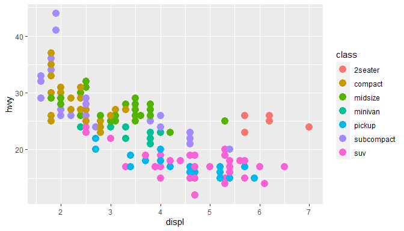

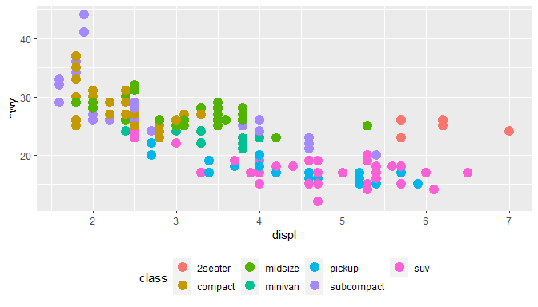

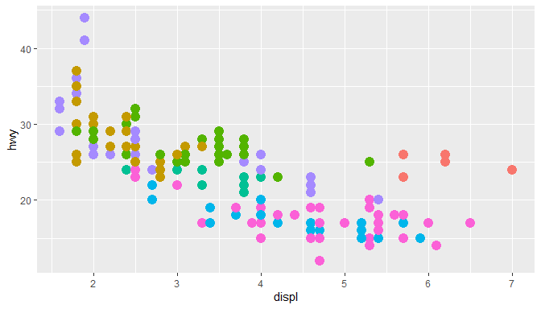

```r
my_plot + theme(legend.position = "right") # default
my_plot + theme(legend.position = "bottom")
my_plot + theme(legend.position = "none")
```

Setting the `legend.position` to “none” within the `theme()` call has the advantage that you don’t have to set `show.legend = FALSE` for every geom.

## 4.2 Guides

The guide functions, `guide_colourbar()` and `guide_legend()`, offer additional control over the fine details of the legend. As you sometimes want the geoms in the legend to display differently to the geoms in the plot, you can override them and set them to a new value. You can do this using the `override.aes` parameter of `guide_legend()`.

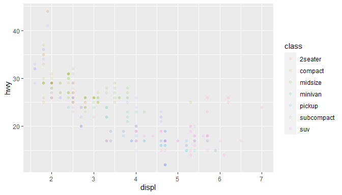

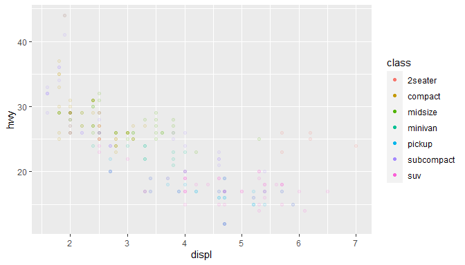

```r
my_plot
my_plot + guides(colour = guide_legend(override.aes = list(alpha = 1)))
```

You can override the default guide using the guide argument of the corresponding scale function, or more conveniently, the `guides()` helper function. `guides()` works like `labs()`: you can override the default guide associated with each aesthetic.

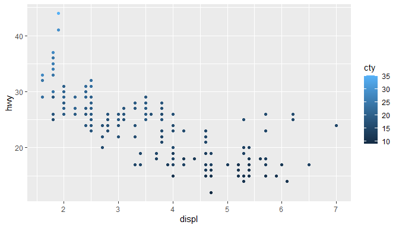

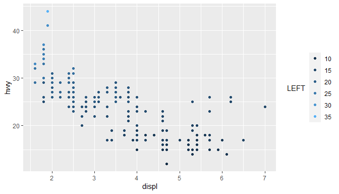

```r
my_plot
my_plot + scale_colour_continuous(guide = guide_legend(title = "LEFT", title.position = "left"))
```

The most useful options for guide_legend are: 1. `nrow` or `ncol` which specify the dimensions of the table. `byrow` controls how the table is filled: `FALSE` fills it by column (the default), `TRUE` fills it by row.

2. `reverse` reverses the order of the keys. This is particularly useful when you have stacked bars because the default stacking and legend orders are different by default.
3. `override.aes` overrides some of the aesthetic settings derived from each layer. This is useful if you want to make the elements in the legend more visually prominent.
4. `keywidth` and `keyheight` (along with `default.unit`) allow you to specify the size of the keys. These are grid units, e.g. `unit(1, "cm")`.